# Pandas-Bootcamp-Part8

#### Highlights

- Split - apply - combine in detail
- manually then using groupby()
- groupby() mechanics and Lazy Evaluation
- Aggregation functions
- grouping by multiple keys
- groupby() , transform() , filter() , apply()

```python
import pandas as pd
import numpy as np
```

#### New Data: Game Sales

```
https://andybek.com/pandas-games
```

```python
games = pd.read_csv('games_sales.csv')
```

```python
games.head()
```

|  | Name | Platform | Year | Genre | Publisher | NA_Sales | EU_Sales | JP_Sales | Other_Sales | Global_Sales |
| --- | --- | --- | --- | --- | --- | --- | --- | --- | --- | --- |
| 0 | Kinect Adventures! | X360 | 2010.0 | Misc | Microsoft Game Studios | 14.97 | 4.94 | 0.24 | 1.67 | 21.82 |
| 1 | Grand Theft Auto V | PS3 | 2013.0 | Action | Take-Two Interactive | 7.01 | 9.27 | 0.97 | 4.14 | 21.40 |
| 2 | Grand Theft Auto V | X360 | 2013.0 | Action | Take-Two Interactive | 9.63 | 5.31 | 0.06 | 1.38 | 16.38 |
| 3 | Call of Duty: Modern Warfare 3 | X360 | 2011.0 | Shooter | Activision | 9.03 | 4.28 | 0.13 | 1.32 | 14.76 |
| 4 | Call of Duty: Black Ops | X360 | 2010.0 | Shooter | Activision | 9.67 | 3.73 | 0.11 | 1.13 | 14.64 |

This is a dataset that contains "sales" information on the most popular games for the XBOX and Playstation Consoles.

```python
#take a look at structure of the df
games.info()
```

```
<class 'pandas.core.frame.DataFrame'>
RangeIndex: 3143 entries, 0 to 3142
Data columns (total 10 columns):
 #   Column        Non-Null Count  Dtype
---  ------        --------------  -----
 0   Name          3143 non-null   object
 1   Platform      3143 non-null   object
 2   Year          3088 non-null   float64
 3   Genre         3143 non-null   object
 4   Publisher     3136 non-null   object
 5   NA_Sales      3143 non-null   float64
 6   EU_Sales      3143 non-null   float64
 7   JP_Sales      3143 non-null   float64
 8   Other_Sales   3143 non-null   float64
 9   Global_Sales  3143 non-null   float64
dtypes: float64(6), object(4)
memory usage: 245.7+ KB
```

- We have about 3000 games in our dataset
- There are 10 columns
- four object columns

```python
#Simple Aggregations : mean , sum , std , var
```

#### What are the Total Sales across all Regions

```python
games.head()
```

|  | Name | Platform | Year | Genre | Publisher | NA_Sales | EU_Sales | JP_Sales | Other_Sales | Global_Sales |
| --- | --- | --- | --- | --- | --- | --- | --- | --- | --- | --- |
| 0 | Kinect Adventures! | X360 | 2010.0 | Misc | Microsoft Game Studios | 14.97 | 4.94 | 0.24 | 1.67 | 21.82 |
| 1 | Grand Theft Auto V | PS3 | 2013.0 | Action | Take-Two Interactive | 7.01 | 9.27 | 0.97 | 4.14 | 21.40 |
| 2 | Grand Theft Auto V | X360 | 2013.0 | Action | Take-Two Interactive | 9.63 | 5.31 | 0.06 | 1.38 | 16.38 |
| 3 | Call of Duty: Modern Warfare 3 | X360 | 2011.0 | Shooter | Activision | 9.03 | 4.28 | 0.13 | 1.32 | 14.76 |
| 4 | Call of Duty: Black Ops | X360 | 2010.0 | Shooter | Activision | 9.67 | 3.73 | 0.11 | 1.13 | 14.64 |

```python
games.columns
```

```
Index(['Name', 'Platform', 'Year', 'Genre', 'Publisher', 'NA_Sales',
       'EU_Sales', 'JP_Sales', 'Other_Sales', 'Global_Sales'],
      dtype='object')
```

```python
#NA_Sales to Other_Sales (leave Global_Sales)
```

```python
games.loc[: , 'NA_Sales' : 'Other_Sales'].sum()
```

```
NA_Sales       1173.30
EU_Sales        793.64
JP_Sales        107.06
Other_Sales     282.75
dtype: float64
```

```python
games.loc[: , 'NA_Sales' : 'Other_Sales'].sum().values
```

```
array([1173.3 ,  793.64,  107.06,  282.75])
```

```python
(games.loc[: , 'NA_Sales' : 'Other_Sales'].sum().values).sum()
```

```
2356.749999999944
```

- Total Sales across all regions is 2356.74

Note :

- Like we have column wise Aggregation .
- Similarly , any Row can be Aggregated across all of its columns
- By default Pandas aggregates vertically (column wise)

```python
games.select_dtypes(np.number).sum(axis = 0)
```

```
Year            6210506.00
NA_Sales           1173.30
EU_Sales            793.64
JP_Sales            107.06
Other_Sales         282.75
Global_Sales       2356.96
dtype: float64
```

```python
#We are doing horizontal aggregation across 3000 rows
```

```python
(games.loc[: , 'NA_Sales' : 'Other_Sales']).sum(axis = 1)
```

```
0       21.82
1       21.39
2       16.38
3       14.76
4       14.64
        ...
3138     0.01
3139     0.01
3140     0.01
3141     0.01
3142     0.01
Length: 3143, dtype: float64
```

#### - Important take away : We can Aggregate horizontally or Vertically

### Conditional Aggregates

Functions that are applied to smaller set of values within the DataFrame.

We are still applying the same function, but we want to keep the results from each group Separate.

- Lets say we want to get "Total Sales By Region" for only two of the platforms.

```python
games.head(1)
```

|  | Name | Platform | Year | Genre | Publisher | NA_Sales | EU_Sales | JP_Sales | Other_Sales | Global_Sales |
| --- | --- | --- | --- | --- | --- | --- | --- | --- | --- | --- |
| 0 | Kinect Adventures! | X360 | 2010.0 | Misc | Microsoft Game Studios | 14.97 | 4.94 | 0.24 | 1.67 | 21.82 |

```python
games.Platform.unique()
```

```
array(['X360', 'PS3', 'PS4', 'XOne'], dtype=object)
```

- We have 4 unique Platforms

#### Find the Total Sales by Region for X360 and PS3

```python
#We could start by creating a new view that only includes the "Platform" and the "Sales" columns
```

```python
games.columns
```

```
Index(['Name', 'Platform', 'Year', 'Genre', 'Publisher', 'NA_Sales',
       'EU_Sales', 'JP_Sales', 'Other_Sales', 'Global_Sales'],
      dtype='object')
```

```python
sales = games[['Platform' , 'NA_Sales',
       'EU_Sales', 'JP_Sales', 'Other_Sales']]
```

```python
#sales = games.loc[: , ['Platform' , 'NA_Sales',EU_Sales', 'JP_Sales', 'Other_Sales']]
```

```python
sales
```

|  | Platform | NA_Sales | EU_Sales | JP_Sales | Other_Sales |
| --- | --- | --- | --- | --- | --- |
| 0 | X360 | 14.97 | 4.94 | 0.24 | 1.67 |
| 1 | PS3 | 7.01 | 9.27 | 0.97 | 4.14 |
| 2 | X360 | 9.63 | 5.31 | 0.06 | 1.38 |
| 3 | X360 | 9.03 | 4.28 | 0.13 | 1.32 |
| 4 | X360 | 9.67 | 3.73 | 0.11 | 1.13 |
| ... | ... | ... | ... | ... | ... |
| 3138 | X360 | 0.00 | 0.01 | 0.00 | 0.00 |
| 3139 | XOne | 0.01 | 0.00 | 0.00 | 0.00 |
| 3140 | XOne | 0.01 | 0.00 | 0.00 | 0.00 |
| 3141 | PS4 | 0.00 | 0.01 | 0.00 | 0.00 |
| 3142 | XOne | 0.00 | 0.01 | 0.00 | 0.00 |

3143 rows × 5 columns

```python
#Sales Totals across all Dataframe Rows
sales.sum(numeric_only = True)
```

```
NA_Sales       1173.30
EU_Sales        793.64
JP_Sales        107.06
Other_Sales     282.75
dtype: float64
```

```python
#Total Sales by Region for X360 and PS3
#We have to be a bit more specific regarding Data Selection
```

#### Region wise Sales for XBOX 360

```python
#We have selected only 'X360'
sales.loc[games.Platform == 'X360']
```

|  | Platform | NA_Sales | EU_Sales | JP_Sales | Other_Sales |
| --- | --- | --- | --- | --- | --- |
| 0 | X360 | 14.97 | 4.94 | 0.24 | 1.67 |
| 2 | X360 | 9.63 | 5.31 | 0.06 | 1.38 |
| 3 | X360 | 9.03 | 4.28 | 0.13 | 1.32 |
| 4 | X360 | 9.67 | 3.73 | 0.11 | 1.13 |
| 7 | X360 | 8.25 | 4.30 | 0.07 | 1.12 |
| ... | ... | ... | ... | ... | ... |
| 3127 | X360 | 0.00 | 0.01 | 0.00 | 0.00 |
| 3128 | X360 | 0.00 | 0.00 | 0.01 | 0.00 |
| 3130 | X360 | 0.01 | 0.00 | 0.00 | 0.00 |
| 3135 | X360 | 0.00 | 0.00 | 0.01 | 0.00 |
| 3138 | X360 | 0.00 | 0.01 | 0.00 | 0.00 |

1265 rows × 5 columns

```python
sales.loc[games.Platform == 'X360'].sum(numeric_only = True)
```

```
NA_Sales       601.05
EU_Sales       280.58
JP_Sales        12.43
Other_Sales     85.54
dtype: float64
```

```python
#we can do the same for PS3
sales.loc[games.Platform == 'PS3']
```

|  | Platform | NA_Sales | EU_Sales | JP_Sales | Other_Sales |
| --- | --- | --- | --- | --- | --- |
| 1 | PS3 | 7.01 | 9.27 | 0.97 | 4.14 |
| 6 | PS3 | 4.99 | 5.88 | 0.65 | 2.52 |
| 9 | PS3 | 5.54 | 5.82 | 0.49 | 1.62 |
| 10 | PS3 | 5.98 | 4.44 | 0.48 | 1.83 |
| 14 | PS3 | 2.96 | 4.88 | 0.81 | 2.12 |
| ... | ... | ... | ... | ... | ... |
| 3124 | PS3 | 0.00 | 0.01 | 0.00 | 0.00 |
| 3125 | PS3 | 0.00 | 0.00 | 0.01 | 0.00 |
| 3129 | PS3 | 0.00 | 0.00 | 0.01 | 0.00 |
| 3132 | PS3 | 0.00 | 0.00 | 0.01 | 0.00 |
| 3136 | PS3 | 0.00 | 0.00 | 0.01 | 0.00 |

1329 rows × 5 columns

```python
sales.loc[games.Platform == 'PS3'].sum(numeric_only = True)
```

```
NA_Sales       392.26
EU_Sales       343.71
JP_Sales        79.99
Other_Sales    141.93
dtype: float64
```

#### The above approach is quite repititive

What if you have to calculate the Totals for 100s of categories

#### The spli() - apply() - combine() pattern

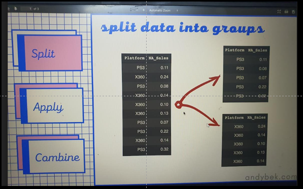

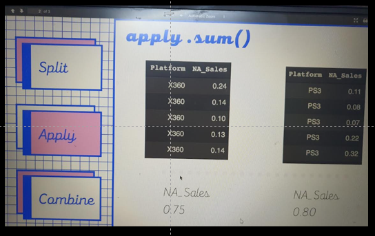

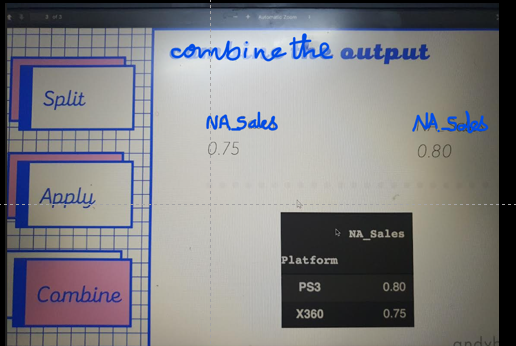

So far in this section we have broken down our dataset into smaller chunks and we have operated on the chunks individually. This is very similar to the split() and apply() steps. What we have NOT done is : Put these two pieces together in one unified Data Structure.

#### The groupby() method implements all these three steps in one single operation

### The groupby() method

```python
sales
```

|  | Platform | NA_Sales | EU_Sales | JP_Sales | Other_Sales |
| --- | --- | --- | --- | --- | --- |
| 0 | X360 | 14.97 | 4.94 | 0.24 | 1.67 |
| 1 | PS3 | 7.01 | 9.27 | 0.97 | 4.14 |
| 2 | X360 | 9.63 | 5.31 | 0.06 | 1.38 |
| 3 | X360 | 9.03 | 4.28 | 0.13 | 1.32 |
| 4 | X360 | 9.67 | 3.73 | 0.11 | 1.13 |
| ... | ... | ... | ... | ... | ... |
| 3138 | X360 | 0.00 | 0.01 | 0.00 | 0.00 |
| 3139 | XOne | 0.01 | 0.00 | 0.00 | 0.00 |
| 3140 | XOne | 0.01 | 0.00 | 0.00 | 0.00 |
| 3141 | PS4 | 0.00 | 0.01 | 0.00 | 0.00 |
| 3142 | XOne | 0.00 | 0.01 | 0.00 | 0.00 |

3143 rows × 5 columns

#### Find the Total Sales by Region for X360 and PS3

```python
#Since we want to split our groups by Platform  : X360 and PS3
#so we group by 'Platform'
```

```python
sales.groupby('Platform').sum()
```

| Platform | NA_Sales | EU_Sales | JP_Sales | Other_Sales |
| --- | --- | --- | --- | --- |
| PS3 | 392.26 | 343.71 | 79.99 | 141.93 |
| PS4 | 96.80 | 123.70 | 14.30 | 43.36 |
| X360 | 601.05 | 280.58 | 12.43 | 85.54 |
| XOne | 83.19 | 45.65 | 0.34 | 11.92 |

```python
#We could apply any function here
```

#### How much does each Platform sell across all regions on Average?

```python
sales.groupby('Platform').mean()
```

| Platform | NA_Sales | EU_Sales | JP_Sales | Other_Sales |
| --- | --- | --- | --- | --- |
| PS3 | 0.295154 | 0.258623 | 0.060188 | 0.106795 |
| PS4 | 0.288095 | 0.368155 | 0.042560 | 0.129048 |
| X360 | 0.475138 | 0.221802 | 0.009826 | 0.067621 |
| XOne | 0.390563 | 0.214319 | 0.001596 | 0.055962 |

```python
#if we look at the median()
#median() values are less than half of the mean()
#Since mean() is significantly greater than the median() , its a skewed distribution
sales.groupby('Platform').median()
```

| Platform | NA_Sales | EU_Sales | JP_Sales | Other_Sales |
| --- | --- | --- | --- | --- |
| PS3 | 0.12 | 0.07 | 0.01 | 0.03 |
| PS4 | 0.07 | 0.08 | 0.02 | 0.03 |
| X360 | 0.17 | 0.06 | 0.00 | 0.02 |
| XOne | 0.15 | 0.07 | 0.00 | 0.02 |

We use groupby() to carry out a split() , apply() , combine() type of operation

- The method splits the dataframe by the key that we provide
- In this case 'Platform'
- groups the data by Platform (as many groups as there are categories)
- Then apply a function
- And then put back the resulting output in one nice Data Structure

### The DataFrame groupby() Object

Lets take a closer look at the output of groupby() method before the aggregate function is applied

```python
sales.groupby('Platform').sum()
```

| Platform | NA_Sales | EU_Sales | JP_Sales | Other_Sales |
| --- | --- | --- | --- | --- |
| PS3 | 392.26 | 343.71 | 79.99 | 141.93 |
| PS4 | 96.80 | 123.70 | 14.30 | 43.36 |
| X360 | 601.05 | 280.58 | 12.43 | 85.54 |
| XOne | 83.19 | 45.65 | 0.34 | 11.92 |

```python
sales.groupby('Platform')
```

```
<pandas.core.groupby.generic.DataFrameGroupBy object at 0x00000232D33A7130>
```

- We see an interesting DataFrame groupby object
- Think of this as a special view into an intermediate output
- At this stage Pandas has kind of split our dataset into sub-groups
- And , is waiting for instructions as to what to do next
- Its not into the apply step yet
- Its not yet split also
- Its just validated our mapping ans waiting

```python
#Lets look at the len of dataframe groupby object
len(sales.groupby('Platform'))
```

```
4
```

```python
sales.Platform.unique()
```

```
array(['X360', 'PS3', 'PS4', 'XOne'], dtype=object)
```

4 groups created for 4 categories

This concept of sitting and waiting is called "Lazy Evaluation" in computer terms : Meaning : No computation or calculation is takes place until it is needed or called for.

#### Key Note :

Applying "groupby()" on a DataFrame returns a DataFrame group by Object and not a DataFrame

### Customizing Index to group Mappings

```python
#equivalent to:
sales.groupby(sales['Platform']).sum()
```

| Platform | NA_Sales | EU_Sales | JP_Sales | Other_Sales |
| --- | --- | --- | --- | --- |
| PS3 | 392.26 | 343.71 | 79.99 | 141.93 |
| PS4 | 96.80 | 123.70 | 14.30 | 43.36 |
| X360 | 601.05 | 280.58 | 12.43 | 85.54 |
| XOne | 83.19 | 45.65 | 0.34 | 11.92 |

```python
#Lets say we do not want to group by as many unique values as the column has
#or as many categories as the column has
#Lets say instead of all 4 sub-groups , we want to see only 2
#Playstation and XBOX
#PS3 and PS4 ::: Playstation
#X360 and XOne ::: XBOX
```

```python
#say we have this Dictionary
Platform_Names  = {
    'PS3' : 'Playstation',
    'PS4' : 'Playstation',
    'X360': 'XBOX',
    'XOne': 'XBOX'
}
```

```python
Platform_Names
```

```
{'PS3': 'Playstation', 'PS4': 'Playstation', 'X360': 'XBOX', 'XOne': 'XBOX'}
```

```python
#Lets set 'Platform' as the Index of our dataframe
sales.set_index('Platform')
```

| Platform | NA_Sales | EU_Sales | JP_Sales | Other_Sales |
| --- | --- | --- | --- | --- |
| X360 | 14.97 | 4.94 | 0.24 | 1.67 |
| PS3 | 7.01 | 9.27 | 0.97 | 4.14 |
| X360 | 9.63 | 5.31 | 0.06 | 1.38 |
| X360 | 9.03 | 4.28 | 0.13 | 1.32 |
| X360 | 9.67 | 3.73 | 0.11 | 1.13 |
| ... | ... | ... | ... | ... |
| X360 | 0.00 | 0.01 | 0.00 | 0.00 |
| XOne | 0.01 | 0.00 | 0.00 | 0.00 |
| XOne | 0.01 | 0.00 | 0.00 | 0.00 |
| PS4 | 0.00 | 0.01 | 0.00 | 0.00 |
| XOne | 0.00 | 0.01 | 0.00 | 0.00 |

3143 rows × 4 columns

```python
sales.set_index('Platform').groupby(Platform_Names).sum()
```

|  | NA_Sales | EU_Sales | JP_Sales | Other_Sales |
| --- | --- | --- | --- | --- |
| Playstation | 489.06 | 467.41 | 94.29 | 185.29 |
| XBOX | 684.24 | 326.23 | 12.77 | 97.46 |

### Alternatively

```python
#sales['Platform'].replace({'XOne' : 'XBOX' , 'X360' : 'XBOX' , 'PS4' : 'Playstation' , 'PS3' : 'Playstation'})
sales['Platform'].replace(Platform_Names)
```

```
0              XBOX
1       Playstation
2              XBOX
3              XBOX
4              XBOX
           ...
3138           XBOX
3139           XBOX
3140           XBOX
3141    Playstation
3142           XBOX
Name: Platform, Length: 3143, dtype: object
```

```python
sales2 = sales.copy()
```

```python
sales2['Platform'] = sales2['Platform'].replace(Platform_Names)
```

```python
sales2
```

|  | Platform | NA_Sales | EU_Sales | JP_Sales | Other_Sales |
| --- | --- | --- | --- | --- | --- |
| 0 | XBOX | 14.97 | 4.94 | 0.24 | 1.67 |
| 1 | Playstation | 7.01 | 9.27 | 0.97 | 4.14 |
| 2 | XBOX | 9.63 | 5.31 | 0.06 | 1.38 |
| 3 | XBOX | 9.03 | 4.28 | 0.13 | 1.32 |
| 4 | XBOX | 9.67 | 3.73 | 0.11 | 1.13 |
| ... | ... | ... | ... | ... | ... |
| 3138 | XBOX | 0.00 | 0.01 | 0.00 | 0.00 |
| 3139 | XBOX | 0.01 | 0.00 | 0.00 | 0.00 |
| 3140 | XBOX | 0.01 | 0.00 | 0.00 | 0.00 |
| 3141 | Playstation | 0.00 | 0.01 | 0.00 | 0.00 |
| 3142 | XBOX | 0.00 | 0.01 | 0.00 | 0.00 |

3143 rows × 5 columns

```python
sales2.groupby('Platform').sum()
```

| Platform | NA_Sales | EU_Sales | JP_Sales | Other_Sales |
| --- | --- | --- | --- | --- |
| Playstation | 489.06 | 467.41 | 94.29 | 185.29 |
| XBOX | 684.24 | 326.23 | 12.77 | 97.46 |

### Series groupby()

#### groupby --> split - apply - combine

```python
#Lets pick "Genre" and "Global_sales" from our DataFrame
#set "Genre" as Index
games.loc[: , ['Genre' , 'Global_Sales']].set_index('Genre')
```

| Genre | Global_Sales |
| --- | --- |
| Misc | 21.82 |
| Action | 21.40 |
| Action | 16.38 |
| Shooter | 14.76 |
| Shooter | 14.64 |
| ... | ... |
| Role-Playing | 0.01 |
| Platform | 0.01 |
| Shooter | 0.01 |
| Simulation | 0.01 |
| Sports | 0.01 |

3143 rows × 1 columns

- Notice that , even though we have a single sequence of values with associated labels, this is still a DataFame

```python
type(games.loc[: , ['Genre' , 'Global_Sales']].set_index('Genre'))
```

```
pandas.core.frame.DataFrame
```

```python
(games.loc[: , ['Genre' , 'Global_Sales']].set_index('Genre')).shape
```

```
(3143, 1)
```

```python
(games.loc[: , ['Genre' , 'Global_Sales']].set_index('Genre')).columns
```

```
Index(['Global_Sales'], dtype='object')
```

```python
#Lets use the squeeze() method here to get a Series out of this
games.loc[: , ['Genre' , 'Global_Sales']].set_index('Genre').squeeze()
```

```
Genre
Misc            21.82
Action          21.40
Action          16.38
Shooter         14.76
Shooter         14.64
                ...
Role-Playing     0.01
Platform         0.01
Shooter          0.01
Simulation       0.01
Sports           0.01
Name: Global_Sales, Length: 3143, dtype: float64
```

```python
type(games.loc[: , ['Genre' , 'Global_Sales']].set_index('Genre').squeeze())
```

```
pandas.core.series.Series
```

```python
ser = games.loc[: , ['Genre' , 'Global_Sales']].set_index('Genre').squeeze()
```

```python
#lets look at first 10 records
ser.head(10)
```

```
Genre
Misc       21.82
Action     21.40
Action     16.38
Shooter    14.76
Shooter    14.64
Shooter    14.24
Shooter    14.03
Shooter    13.73
Shooter    13.51
Shooter    13.46
Name: Global_Sales, dtype: float64
```

- Now we are working with a series that has "Genre" as the Index and the "Global_sales" for each game as values
- If we now want to calculate the Average Global Sales by Genre, we can simply apply groupby to this entire series

### Average Sales by Genre

```python
ser.groupby('Genre').mean()
```

```
Genre
Action          0.751007
Adventure       0.298289
Fighting        0.604182
Misc            0.550250
Platform        0.651842
Puzzle          0.133636
Racing          0.687854
Role-Playing    0.715804
Shooter         1.412019
Simulation      0.336076
Sports          0.681094
Strategy        0.264333
Name: Global_Sales, dtype: float64
```

```python
#We can sort it
ser.groupby('Genre').mean().sort_values(ascending = False)
```

```
Genre
Shooter         1.412019
Action          0.751007
Role-Playing    0.715804
Racing          0.687854
Sports          0.681094
Platform        0.651842
Fighting        0.604182
Misc            0.550250
Simulation      0.336076
Adventure       0.298289
Strategy        0.264333
Puzzle          0.133636
Name: Global_Sales, dtype: float64
```

- Shooter , Action and Role playing games are the best selling with "shooter" category selling almost twice as much as the next best selling category.

### Skill Challenge

#### Create a smaller Dataframe from games, selecting only the 'Publisher' , 'Genre' , 'Platform' and 'NA_Sales' columns. Assign this DataFrame to the variable 'Publishers'

https://www.udemy.com/course/the-ultimate-pandas-bootcamp-advanced-python-data-analysis/learn/lecture/19269326#questions/13647656

```python
games.head(2)
```

|  | Name | Platform | Year | Genre | Publisher | NA_Sales | EU_Sales | JP_Sales | Other_Sales | Global_Sales |
| --- | --- | --- | --- | --- | --- | --- | --- | --- | --- | --- |
| 0 | Kinect Adventures! | X360 | 2010.0 | Misc | Microsoft Game Studios | 14.97 | 4.94 | 0.24 | 1.67 | 21.82 |
| 1 | Grand Theft Auto V | PS3 | 2013.0 | Action | Take-Two Interactive | 7.01 | 9.27 | 0.97 | 4.14 | 21.40 |

```python
publishers = games[['Publisher','Platform' , 'Genre', 'NA_Sales']]
```

```python
publishers.head(2)
```

|  | Publisher | Platform | Genre | NA_Sales |
| --- | --- | --- | --- | --- |
| 0 | Microsoft Game Studios | X360 | Misc | 14.97 |
| 1 | Take-Two Interactive | PS3 | Action | 7.01 |

#### From the 'publishers' dataframe , find the Top 10 game publishers in North America by Total Sales

```python
publishers.groupby('Publisher').sum().sort_values(by = 'NA_Sales' , ascending = False)
```

| Publisher | NA_Sales |
| --- | --- |
| Electronic Arts | 213.38 |
| Activision | 193.16 |
| Take-Two Interactive | 120.99 |
| Microsoft Game Studios | 116.77 |
| Ubisoft | 98.65 |
| ... | ... |
| Kadokawa Games | 0.00 |
| Falcom Corporation | 0.00 |
| Devolver Digital | 0.00 |
| CyberFront | 0.00 |
| 49Games | 0.00 |

155 rows × 1 columns

```python
#Top 10 game publishers
publishers.groupby('Publisher').sum().sort_values(by = 'NA_Sales' , ascending = False).head(10)
```

| Publisher | NA_Sales |
| --- | --- |
| Electronic Arts | 213.38 |
| Activision | 193.16 |
| Take-Two Interactive | 120.99 |
| Microsoft Game Studios | 116.77 |
| Ubisoft | 98.65 |
| Sony Computer Entertainment | 76.35 |
| Warner Bros. Interactive Entertainment | 45.24 |
| THQ | 36.44 |
| Bethesda Softworks | 33.88 |
| Capcom | 24.74 |

- These are the Top 10 Publishers by North American Sales

#### Similarly , what is the gaming platform that has attracted the most sales in North America?

```python
games.head(2)
```

|  | Name | Platform | Year | Genre | Publisher | NA_Sales | EU_Sales | JP_Sales | Other_Sales | Global_Sales |
| --- | --- | --- | --- | --- | --- | --- | --- | --- | --- | --- |
| 0 | Kinect Adventures! | X360 | 2010.0 | Misc | Microsoft Game Studios | 14.97 | 4.94 | 0.24 | 1.67 | 21.82 |
| 1 | Grand Theft Auto V | PS3 | 2013.0 | Action | Take-Two Interactive | 7.01 | 9.27 | 0.97 | 4.14 | 21.40 |

```python
plat = games[['Platform' , 'NA_Sales']]
```

```python
plat.head(2)
```

|  | Platform | NA_Sales |
| --- | --- | --- |
| 0 | X360 | 14.97 |
| 1 | PS3 | 7.01 |

```python
plat['Platform'].unique()
```

```
array(['X360', 'PS3', 'PS4', 'XOne'], dtype=object)
```

```python
platform_names = {
    'X360' : 'XBOX',
    'XOne' : 'XBOX',
    'PS3'  : 'Playstation',
    'PS4'  : 'Playstation'
}
```

```python
plat['Platform'].replace(platform_names)
```

```
0              XBOX
1       Playstation
2              XBOX
3              XBOX
4              XBOX
           ...
3138           XBOX
3139           XBOX
3140           XBOX
3141    Playstation
3142           XBOX
Name: Platform, Length: 3143, dtype: object
```

```python
plat = plat.copy()
```

```python
plat['Platform'] = plat['Platform'].replace(platform_names)
```

```python
plat.head(2)
```

|  | Platform | NA_Sales |
| --- | --- | --- |
| 0 | XBOX | 14.97 |
| 1 | Playstation | 7.01 |

```python
plat.groupby('Platform').sum().sort_values(by = 'NA_Sales' , ascending = False)
```

| Platform | NA_Sales |
| --- | --- |
| XBOX | 684.24 |
| Playstation | 489.06 |

- XBOX shows the highest sales in NA

### Iterating through Groups

```python
#To see the content of the Dataframe group by object
```

```python
for name,df in plat.groupby('Platform'):
    print('---------------')
    print('Subgroup label: ' , name)
    print('---------------', '\n')
    print(df , '\n')
```

```
---------------
Subgroup label:  Playstation
---------------

         Platform  NA_Sales
1     Playstation      7.01
5     Playstation      5.77
6     Playstation      4.99
9     Playstation      5.54
10    Playstation      5.98
...           ...       ...
3129  Playstation      0.00
3132  Playstation      0.00
3136  Playstation      0.00
3137  Playstation      0.00
3141  Playstation      0.00

[1665 rows x 2 columns]

---------------
Subgroup label:  XBOX
---------------

     Platform  NA_Sales
0        XBOX     14.97
2        XBOX      9.63
3        XBOX      9.03
4        XBOX      9.67
7        XBOX      8.25
...       ...       ...
3135     XBOX      0.00
3138     XBOX      0.00
3139     XBOX      0.01
3140     XBOX      0.01
3142     XBOX      0.00

[1478 rows x 2 columns]
```

This is useful in debugging in general

### HAndpicking Sub-Groups

Lets say we want to view only a single selected Sub-group from the group by Object

- For general purpose , to see whats going on inside or we are doudbtful of the aggregates etc

```python
#We want to view only subgroup "XBOX" from 'Platform'
#For this we need to convert the whole DataFrame object into an iterable.
```

```python
#Now we have a Python Dictionary
#Key and value pairs
dict(iter(plat.groupby('Platform')))
```

```
{'Playstation':          Platform  NA_Sales
 1     Playstation      7.01
 5     Playstation      5.77
 6     Playstation      4.99
 9     Playstation      5.54
 10    Playstation      5.98
 ...           ...       ...
 3129  Playstation      0.00
 3132  Playstation      0.00
 3136  Playstation      0.00
 3137  Playstation      0.00
 3141  Playstation      0.00

 [1665 rows x 2 columns],
 'XBOX':      Platform  NA_Sales
 0        XBOX     14.97
 2        XBOX      9.63
 3        XBOX      9.03
 4        XBOX      9.67
 7        XBOX      8.25
 ...       ...       ...
 3135     XBOX      0.00
 3138     XBOX      0.00
 3139     XBOX      0.01
 3140     XBOX      0.01
 3142     XBOX      0.00

 [1478 rows x 2 columns]}
```

```python
#To access "Playstation"
dict(iter(plat.groupby('Platform')))['Playstation']
```

|  | Platform | NA_Sales |
| --- | --- | --- |
| 1 | Playstation | 7.01 |
| 5 | Playstation | 5.77 |
| 6 | Playstation | 4.99 |
| 9 | Playstation | 5.54 |
| 10 | Playstation | 5.98 |
| ... | ... | ... |
| 3129 | Playstation | 0.00 |
| 3132 | Playstation | 0.00 |
| 3136 | Playstation | 0.00 |
| 3137 | Playstation | 0.00 |
| 3141 | Playstation | 0.00 |

1665 rows × 2 columns

But the above approach is a bit tedious.

For this purpose , Pandas has a method "get_group()"

### get_group()

```python
#We can simply say
plat.groupby('Platform').get_group('Playstation')
```

|  | Platform | NA_Sales |
| --- | --- | --- |
| 1 | Playstation | 7.01 |
| 5 | Playstation | 5.77 |
| 6 | Playstation | 4.99 |
| 9 | Playstation | 5.54 |
| 10 | Playstation | 5.98 |
| ... | ... | ... |
| 3129 | Playstation | 0.00 |
| 3132 | Playstation | 0.00 |
| 3136 | Playstation | 0.00 |
| 3137 | Playstation | 0.00 |
| 3141 | Playstation | 0.00 |

1665 rows × 2 columns

This approach is lot faster

### MultiIndex Grouping

We will group by multiple columns or keys

```python
#We will slice the dataframe with columns we need
studios = games.loc[: , ['Genre' , 'Publisher' , 'Global_Sales']]
```

```python
studios.head(2)
```

|  | Genre | Publisher | Global_Sales |
| --- | --- | --- | --- |
| 0 | Misc | Microsoft Game Studios | 21.82 |
| 1 | Action | Take-Two Interactive | 21.40 |

- We are working with a 3 column dataframe here, each record representing a single game and the columns representing 'Genre' , 'Publisher' as well as the Total "Global_Sales"

#### We are looking at Total Revenue by Publisher

OR

#### Which are the Top publishers by Global Sales?

```python
#groupby single key
studios.groupby('Publisher').sum()\
                            .sort_values(by='Global_Sales' , ascending = False)
```

| Publisher | Global_Sales |
| --- | --- |
| Electronic Arts | 434.41 |
| Activision | 349.22 |
| Take-Two Interactive | 218.08 |
| Ubisoft | 201.98 |
| Microsoft Game Studios | 190.56 |
| ... | ... |
| UIG Entertainment | 0.01 |
| ChunSoft | 0.01 |
| Kaga Create | 0.01 |
| Epic Games | 0.01 |
| Ongakukan | 0.01 |

155 rows × 1 columns

But, this kind of Aggregation quickly proves to be inadequate if we add another dimension to our Question

For Example : We could be interested in . "The best selling publishers within each game "Genre" lead by 'Global_Sales'

But if the question becomes complicated?

#### Which are the Top publishers within each 'Genre' by 'Global_Sales' ?

```python
#Noe we need to pass a list of column names to the group by instead of a singls column
```

```python
studios.groupby(['Genre' , 'Publisher'])
```

```
<pandas.core.groupby.generic.DataFrameGroupBy object at 0x00000267ECE83F10>
```

```python
studios.groupby(['Genre' , 'Publisher']).sum().sort_values(by = 'Global_Sales', ascending = False)
```

| Genre | Publisher | Global_Sales |
| --- | --- | --- |
| Shooter | Activision | 245.46 |
| Sports | Electronic Arts | 203.50 |
| Action | Take-Two Interactive | 106.04 |
|  | Ubisoft | 96.44 |
| Shooter | Electronic Arts | 92.58 |
| ... | ... | ... |
| Adventure | Cave | 0.01 |
| Role-Playing | TopWare Interactive | 0.01 |
| Sports | Interworks Unlimited, Inc. | 0.01 |
| Strategy | Ackkstudios | 0.01 |
| Adventure | Views | 0.01 |

422 rows × 1 columns

- Now we see that , even though "Electronic Arts" is the leading Studio overall, 'Activision' is the leader , because they are generating almost 245 M dollars in Shooter Games

Whenever we use groupby with more than one key, the resulting DataSetructure contains a MultiIndex.

- In the above example we are looking at a two level hierarchical Index consisting of 'Genre' and 'Publisher'

### Fine-Tuned Aggregates

Now we will look at the Aggregation function:

In pandas , all of these codes are identical:

```
- studios.groupby[['Genre' , 'Publisher']].sum()
- studios.groupby[['Genre' , 'Publisher']].aggregate('sum')
- studios.groupby[['Genre' , 'Publisher']].agg('sum')
- studios.groupby[['Genre' , 'Publisher']].agg(np.sum)
```

```python
#agg is short for aggregate
```

The advantage of using the aggregate() function is , it allows us to apply several functions in one go.

- This method accepts Python list of functions as well

#### In addition to looking at the Top selling Publishers within each Genre , we also want to get a sense of "how many games they published" , the Std deviation and the Mean of their sales

#### Q: Summarize the sum , count ,average and the Standard Deviation of Sales as well as the Number of games published by each publisher within each Genre

```python
#Using multiIndex groupby and the agg() function together we can snswer this
```

```python
#We will start by aggregating by 'Genre' and 'Publisher
#Notice the question : "by each publisher within each Genre"
studios.groupby(['Genre' , 'Publisher'])
```

```
<pandas.core.groupby.generic.DataFrameGroupBy object at 0x00000267ECE83520>
```

```python
#We will pass a Python list of functions to the aggregate() function
studios.groupby(['Genre' , 'Publisher']).aggregate(['sum' , 'count' , 'mean' ,'std' ])
```

| Genre | Publisher | Global_Sales sum | Global_Sales count | Global_Sales mean | Global_Sales std |
| --- | --- | --- | --- | --- | --- |
| Action | 505 Games | 2.25 | 8 | 0.281250 | 0.266482 |
|  | Abylight | 0.08 | 1 | 0.080000 | NaN |
|  | Ackkstudios | 0.33 | 1 | 0.330000 | NaN |
|  | Acquire | 0.11 | 1 | 0.110000 | NaN |
|  | Activision | 42.84 | 95 | 0.450947 | 0.559717 |
| ... | ... | ... | ... | ... | ... |
| Strategy | Square Enix | 0.35 | 1 | 0.350000 | NaN |
|  | Takara Tomy | 0.09 | 1 | 0.090000 | NaN |
|  | Take-Two Interactive | 2.92 | 6 | 0.486667 | 0.364289 |
|  | Tecmo Koei | 0.58 | 6 | 0.096667 | 0.055015 |
|  | Ubisoft | 2.34 | 4 | 0.585000 | 0.267519 |

422 rows × 4 columns

- We are getting a couple of NANs under Std deviation. This is for the 'Genre'+'Publisher' combinations that have a Single game. (if n = 1 , the degrees of freedom adjustment in the Std dev formula , results in NAN)
- In the above output , notice that we have created a hierachical index on both the dataframe axes. (two level)
- Now lets asy we want to see the top values at the top and we try to sort it by lets say "Global_Sales"
- We can't
- studios.groupby(['Genre' , 'Publisher']).aggregate(['sum' , 'count' , 'mean' ,'std' ]).sort_values(by = 'Global_Sales')
- will throw an Error. Because it is a Multiindex now.
- For this we need to provide a Tuple

```python
#Sort by "Global_Sales" ---> sum()
studios.groupby(['Genre' , 'Publisher']).agg(['sum' , 'count' , 'mean' ,'std' ])\
                                        .sort_values(by = ('Global_Sales' , 'sum') , ascending = False)
```

| Genre | Publisher | Global_Sales sum | Global_Sales count | Global_Sales mean | Global_Sales std |
| --- | --- | --- | --- | --- | --- |
| Shooter | Activision | 245.46 | 72 | 3.409167 | 4.621920 |
| Sports | Electronic Arts | 203.50 | 170 | 1.197059 | 1.404108 |
| Action | Take-Two Interactive | 106.04 | 23 | 4.610435 | 5.843768 |
|  | Ubisoft | 96.44 | 67 | 1.439403 | 1.636460 |
| Shooter | Electronic Arts | 92.58 | 50 | 1.851600 | 1.794404 |
| ... | ... | ... | ... | ... | ... |
| Adventure | Cave | 0.01 | 1 | 0.010000 | NaN |
| Role-Playing | TopWare Interactive | 0.01 | 1 | 0.010000 | NaN |
| Sports | Interworks Unlimited, Inc. | 0.01 | 1 | 0.010000 | NaN |
| Strategy | Ackkstudios | 0.01 | 1 | 0.010000 | NaN |
| Adventure | Views | 0.01 | 1 | 0.010000 | NaN |

422 rows × 4 columns

- Looking at the 'count' , It appears that "Activision" publishes a lot less games than its closest competitor " Electronic Arts"
- looking at the "mean" , 'Activision' seems to be generating 3 times the revenue per game
- We can find out what games they are publishing

```python
games[games.Publisher == 'Activision'].sort_values('Global_Sales' , ascending = False)
```

|  | Name | Platform | Year | Genre | Publisher | NA_Sales | EU_Sales | JP_Sales | Other_Sales | Global_Sales |
| --- | --- | --- | --- | --- | --- | --- | --- | --- | --- | --- |
| 3 | Call of Duty: Modern Warfare 3 | X360 | 2011.0 | Shooter | Activision | 9.03 | 4.28 | 0.13 | 1.32 | 14.76 |
| 4 | Call of Duty: Black Ops | X360 | 2010.0 | Shooter | Activision | 9.67 | 3.73 | 0.11 | 1.13 | 14.64 |
| 5 | Call of Duty: Black Ops 3 | PS4 | 2015.0 | Shooter | Activision | 5.77 | 5.81 | 0.35 | 2.31 | 14.24 |
| 6 | Call of Duty: Black Ops II | PS3 | 2012.0 | Shooter | Activision | 4.99 | 5.88 | 0.65 | 2.52 | 14.03 |
| 7 | Call of Duty: Black Ops II | X360 | 2012.0 | Shooter | Activision | 8.25 | 4.30 | 0.07 | 1.12 | 13.73 |
| ... | ... | ... | ... | ... | ... | ... | ... | ... | ... | ... |
| 2923 | Ghostbusters (2016) | XOne | 2016.0 | Action | Activision | 0.02 | 0.00 | 0.00 | 0.00 | 0.02 |
| 2932 | The Voice | PS3 | 2014.0 | Action | Activision | 0.02 | 0.00 | 0.00 | 0.00 | 0.02 |
| 2935 | Rapala for Kinect | X360 | 2011.0 | Sports | Activision | 0.00 | 0.02 | 0.00 | 0.00 | 0.02 |
| 3012 | Call of Duty: Modern Warfare Trilogy | PS3 | 2016.0 | Shooter | Activision | 0.00 | 0.01 | 0.00 | 0.00 | 0.02 |
| 3035 | Call of Duty: Modern Warfare Trilogy | X360 | 2016.0 | Shooter | Activision | 0.01 | 0.01 | 0.00 | 0.00 | 0.02 |

283 rows × 10 columns

- Call of Duty: Modern Warfare 3 , Call of Duty: Black Ops ,,,,,,these are definitely major hits

### Named Aggregates

```python
#What if we want to rename the Aggregate functions
#remember , the rename method works on both axes
#We need to specify the axis for rename
```

```python
studios.groupby(['Genre' , 'Publisher']).agg(['sum' , 'count' , 'mean' ,'std' ])\
        .rename({'sum' : 'Total_Revenue' , 'count' : "Num_games"}, axis = 1)
```

| Genre | Publisher | Global_Sales Total_Revenue | Global_Sales Num_games | Global_Sales mean | Global_Sales std |
| --- | --- | --- | --- | --- | --- |
| Action | 505 Games | 2.25 | 8 | 0.281250 | 0.266482 |
|  | Abylight | 0.08 | 1 | 0.080000 | NaN |
|  | Ackkstudios | 0.33 | 1 | 0.330000 | NaN |
|  | Acquire | 0.11 | 1 | 0.110000 | NaN |
|  | Activision | 42.84 | 95 | 0.450947 | 0.559717 |
| ... | ... | ... | ... | ... | ... |
| Strategy | Square Enix | 0.35 | 1 | 0.350000 | NaN |
|  | Takara Tomy | 0.09 | 1 | 0.090000 | NaN |
|  | Take-Two Interactive | 2.92 | 6 | 0.486667 | 0.364289 |
|  | Tecmo Koei | 0.58 | 6 | 0.096667 | 0.055015 |
|  | Ubisoft | 2.34 | 4 | 0.585000 | 0.267519 |

422 rows × 4 columns

```python
#Names Aggregations
```

```python
#Instead of chaining the rename method , we can do it this way
```

```python
studios.head(2)
```

|  | Genre | Publisher | Global_Sales |
| --- | --- | --- | --- |
| 0 | Misc | Microsoft Game Studios | 21.82 |
| 1 | Action | Take-Two Interactive | 21.40 |

```python
studios.groupby(['Genre' , 'Publisher']) \
                        .agg(total_revenue =('Global_Sales' , 'sum') , num_games = ('Global_Sales' , np.mean))
```

| Genre | Publisher | total_revenue | num_games |
| --- | --- | --- | --- |
| Action | 505 Games | 2.25 | 0.281250 |
|  | Abylight | 0.08 | 0.080000 |
|  | Ackkstudios | 0.33 | 0.330000 |
|  | Acquire | 0.11 | 0.110000 |
|  | Activision | 42.84 | 0.450947 |
| ... | ... | ... | ... |
| Strategy | Square Enix | 0.35 | 0.350000 |
|  | Takara Tomy | 0.09 | 0.090000 |
|  | Take-Two Interactive | 2.92 | 0.486667 |
|  | Tecmo Koei | 0.58 | 0.096667 |
|  | Ubisoft | 2.34 | 0.585000 |

422 rows × 2 columns

```python
studios.groupby(['Genre' , 'Publisher']).agg(
    total_revenue =('Global_Sales' , 'sum') ,
    num_games = ('Global_Sales' , np.mean) ,
    revenue_std = ('Global_Sales' , 'std'),
    revenue_avg = ('Global_Sales' , 'mean')
    )
```

| Genre | Publisher | total_revenue | num_games | revenue_std | revenue_avg |
| --- | --- | --- | --- | --- | --- |
| Action | 505 Games | 2.25 | 0.281250 | 0.266482 | 0.281250 |
|  | Abylight | 0.08 | 0.080000 | NaN | 0.080000 |
|  | Ackkstudios | 0.33 | 0.330000 | NaN | 0.330000 |
|  | Acquire | 0.11 | 0.110000 | NaN | 0.110000 |
|  | Activision | 42.84 | 0.450947 | 0.559717 | 0.450947 |
| ... | ... | ... | ... | ... | ... |
| Strategy | Square Enix | 0.35 | 0.350000 | NaN | 0.350000 |
|  | Takara Tomy | 0.09 | 0.090000 | NaN | 0.090000 |
|  | Take-Two Interactive | 2.92 | 0.486667 | 0.364289 | 0.486667 |
|  | Tecmo Koei | 0.58 | 0.096667 | 0.055015 | 0.096667 |
|  | Ubisoft | 2.34 | 0.585000 | 0.267519 | 0.585000 |

422 rows × 4 columns

- Now we got a Flat single level column axis

```python
#Now since the column axis is flat , we can chain on the sort method just like usual
studios.groupby(['Genre' , 'Publisher']).agg(
    total_revenue =('Global_Sales' , 'sum') ,
    num_games = ('Global_Sales' , np.mean) ,
    revenue_std = ('Global_Sales' , 'std'),
    revenue_avg = ('Global_Sales' , 'mean')
    ).sort_values(by = 'total_revenue' , ascending = False)
```

| Genre | Publisher | total_revenue | num_games | revenue_std | revenue_avg |
| --- | --- | --- | --- | --- | --- |
| Shooter | Activision | 245.46 | 3.409167 | 4.621920 | 3.409167 |
| Sports | Electronic Arts | 203.50 | 1.197059 | 1.404108 | 1.197059 |
| Action | Take-Two Interactive | 106.04 | 4.610435 | 5.843768 | 4.610435 |
|  | Ubisoft | 96.44 | 1.439403 | 1.636460 | 1.439403 |
| Shooter | Electronic Arts | 92.58 | 1.851600 | 1.794404 | 1.851600 |
| ... | ... | ... | ... | ... | ... |
| Adventure | Cave | 0.01 | 0.010000 | NaN | 0.010000 |
| Role-Playing | TopWare Interactive | 0.01 | 0.010000 | NaN | 0.010000 |
| Sports | Interworks Unlimited, Inc. | 0.01 | 0.010000 | NaN | 0.010000 |
| Strategy | Ackkstudios | 0.01 | 0.010000 | NaN | 0.010000 |
| Adventure | Views | 0.01 | 0.010000 | NaN | 0.010000 |

422 rows × 4 columns

```python
#We can make use of different "columns" for aggregate
games.groupby(['Genre' , 'Publisher']).agg(
    total_global_revenue = ('Global_Sales' , 'sum'),
    average_EU_revenue = ('EU_Sales' , 'mean')
)
```

| Genre | Publisher | total_global_revenue | average_EU_revenue |
| --- | --- | --- | --- |
| Action | 505 Games | 2.25 | 0.131250 |
|  | Abylight | 0.08 | 0.000000 |
|  | Ackkstudios | 0.33 | 0.000000 |
|  | Acquire | 0.11 | 0.000000 |
|  | Activision | 42.84 | 0.143053 |
| ... | ... | ... | ... |
| Strategy | Square Enix | 0.35 | 0.100000 |
|  | Takara Tomy | 0.09 | 0.000000 |
|  | Take-Two Interactive | 2.92 | 0.145000 |
|  | Tecmo Koei | 0.58 | 0.000000 |
|  | Ubisoft | 2.34 | 0.200000 |

422 rows × 2 columns

```python
games.groupby(['Genre' , 'Publisher']).agg(
    total_global_revenue = ('Global_Sales' , 'sum'),
    average_EU_revenue = ('EU_Sales' , 'mean')
).columns
```

```
Index(['total_global_revenue', 'average_EU_revenue'], dtype='object')
```

```python
#Perhaps even better
#Within the Dictionary , we will specify the column we want to aggregate and the function
games.groupby(['Genre' , 'Publisher']).agg(
    {
        'Global_Sales' : 'sum',
        'EU_Sales' : 'mean'

    }
)
```

| Genre | Publisher | Global_Sales | EU_Sales |
| --- | --- | --- | --- |
| Action | 505 Games | 2.25 | 0.131250 |
|  | Abylight | 0.08 | 0.000000 |
|  | Ackkstudios | 0.33 | 0.000000 |
|  | Acquire | 0.11 | 0.000000 |
|  | Activision | 42.84 | 0.143053 |
| ... | ... | ... | ... |
| Strategy | Square Enix | 0.35 | 0.100000 |
|  | Takara Tomy | 0.09 | 0.000000 |
|  | Take-Two Interactive | 2.92 | 0.145000 |
|  | Tecmo Koei | 0.58 | 0.000000 |
|  | Ubisoft | 2.34 | 0.200000 |

422 rows × 2 columns